# Cyclistic Case Study

Author: Abdullaah Odunmbaku

## Processing

The processing stage involves cleaning the data after confirming that it is from a good source and it satisfies the necessary conditions.It also involves confirming that the data is complete, correct and relevant. I chose R studios as the tool to use for this phase of the analysis process. I started by installing and then loading the relevant packages.

```r
library(tidyverse)
library(lubridate)
library(janitor)
library(skimr)
```

Loading datasets into the environment with the correct naming conventions.

```r
June_2021 <- read_csv("202106-divvy-tripdata.csv")
July_2021 <- read_csv("202107-divvy-tripdata.csv")
August_2021 <- read_csv("202108-divvy-tripdata.csv")
September_2021 <- read_csv("202109-divvy-tripdata.csv")
October_2021 <- read_csv("202110-divvy-tripdata.csv")
November_2021 <- read_csv("202111-divvy-tripdata.csv")
December_2021 <- read_csv("202112-divvy-tripdata.csv")
January_2022 <- read_csv("202201-divvy-tripdata.csv")
February_2022 <- read_csv("202202-divvy-tripdata.csv")
March_2022 <- read_csv("202203-divvy-tripdata.csv")
April_2022 <- read_csv("202204-divvy-tripdata.csv")
May_2022 <- read_csv("202205-divvy-tripdata.csv")
```

The next step would ideally be to combine all of the data sets into one single data frame. But first, I confirmed that the data sets include the same column names.

```r
colnames(June_2021)
```

```
 [1] "ride_id"            "rideable_type"      "started_at"
 [4] "ended_at"           "start_station_name" "start_station_id"
 [7] "end_station_name"   "end_station_id"     "start_lat"
[10] "start_lng"          "end_lat"            "end_lng"
[13] "member_casual"
```

```r
colnames(July_2021)
```

```
 [1] "ride_id"            "rideable_type"      "started_at"
 [4] "ended_at"           "start_station_name" "start_station_id"
 [7] "end_station_name"   "end_station_id"     "start_lat"
[10] "start_lng"          "end_lat"            "end_lng"
[13] "member_casual"
```

```r
colnames(August_2021)
```

```
 [1] "ride_id"            "rideable_type"      "started_at"
 [4] "ended_at"           "start_station_name" "start_station_id"
 [7] "end_station_name"   "end_station_id"     "start_lat"
[10] "start_lng"          "end_lat"            "end_lng"
[13] "member_casual"
```

```r
colnames(September_2021)
```

```
 [1] "ride_id"            "rideable_type"      "started_at"
 [4] "ended_at"           "start_station_name" "start_station_id"
 [7] "end_station_name"   "end_station_id"     "start_lat"
[10] "start_lng"          "end_lat"            "end_lng"
[13] "member_casual"
```

```r
colnames(October_2021)
```

```
 [1] "ride_id"            "rideable_type"      "started_at"
 [4] "ended_at"           "start_station_name" "start_station_id"
 [7] "end_station_name"   "end_station_id"     "start_lat"
[10] "start_lng"          "end_lat"            "end_lng"
[13] "member_casual"
```

```r
colnames(November_2021)
```

```
 [1] "ride_id"            "rideable_type"      "started_at"
 [4] "ended_at"           "start_station_name" "start_station_id"
 [7] "end_station_name"   "end_station_id"     "start_lat"
[10] "start_lng"          "end_lat"            "end_lng"
[13] "member_casual"
```

```r
colnames(December_2021)
```

```
 [1] "ride_id"            "rideable_type"      "started_at"
 [4] "ended_at"           "start_station_name" "start_station_id"
 [7] "end_station_name"   "end_station_id"     "start_lat"
[10] "start_lng"          "end_lat"            "end_lng"
[13] "member_casual"
```

```r
colnames(January_2022)
```

```
 [1] "ride_id"            "rideable_type"      "started_at"
 [4] "ended_at"           "start_station_name" "start_station_id"
 [7] "end_station_name"   "end_station_id"     "start_lat"
[10] "start_lng"          "end_lat"            "end_lng"
[13] "member_casual"
```

```r
colnames(February_2022)
```

```
 [1] "ride_id"            "rideable_type"      "started_at"
 [4] "ended_at"           "start_station_name" "start_station_id"
 [7] "end_station_name"   "end_station_id"     "start_lat"
[10] "start_lng"          "end_lat"            "end_lng"
[13] "member_casual"
```

```r
colnames(March_2022)
```

```
 [1] "ride_id"            "rideable_type"      "started_at"
 [4] "ended_at"           "start_station_name" "start_station_id"
 [7] "end_station_name"   "end_station_id"     "start_lat"
[10] "start_lng"          "end_lat"            "end_lng"
[13] "member_casual"
```

```r
colnames(April_2022)
```

```
 [1] "ride_id"            "rideable_type"      "started_at"
 [4] "ended_at"           "start_station_name" "start_station_id"
 [7] "end_station_name"   "end_station_id"     "start_lat"
[10] "start_lng"          "end_lat"            "end_lng"
[13] "member_casual"
```

```r
colnames(May_2022)
```

```
 [1] "ride_id"            "rideable_type"      "started_at"
 [4] "ended_at"           "start_station_name" "start_station_id"
 [7] "end_station_name"   "end_station_id"     "start_lat"
[10] "start_lng"          "end_lat"            "end_lng"
[13] "member_casual"
```

Checking if the columns have the same datatypes.

```r
str(June_2021)
```

```
spec_tbl_df [729,595 × 13] (S3: spec_tbl_df/tbl_df/tbl/data.frame)
 $ ride_id           : chr [1:729595] "99FEC93BA843FB20" "06048DCFC8520CAF" "9598066F68045DF2" "B03C0FE48C412214" ...
 $ rideable_type     : chr [1:729595] "electric_bike" "electric_bike" "electric_bike" "electric_bike" ...
 $ started_at        : POSIXct[1:729595], format: "2021-06-13 14:31:28" "2021-06-04 11:18:02" ...
 $ ended_at          : POSIXct[1:729595], format: "2021-06-13 14:34:11" "2021-06-04 11:24:19" ...
 $ start_station_name: chr [1:729595] NA NA NA NA ...
 $ start_station_id  : chr [1:729595] NA NA NA NA ...
 $ end_station_name  : chr [1:729595] NA NA NA NA ...
 $ end_station_id    : chr [1:729595] NA NA NA NA ...
 $ start_lat         : num [1:729595] 41.8 41.8 41.8 41.8 41.8 ...
 $ start_lng         : num [1:729595] -87.6 -87.6 -87.6 -87.6 -87.6 ...
 $ end_lat           : num [1:729595] 41.8 41.8 41.8 41.8 41.8 ...
 $ end_lng           : num [1:729595] -87.6 -87.6 -87.6 -87.6 -87.6 ...
 $ member_casual     : chr [1:729595] "member" "member" "member" "member" ...
 - attr(*, "spec")=
  .. cols(
  ..   ride_id = col_character(),
  ..   rideable_type = col_character(),
  ..   started_at = col_datetime(format = ""),
  ..   ended_at = col_datetime(format = ""),
  ..   start_station_name = col_character(),
  ..   start_station_id = col_character(),
  ..   end_station_name = col_character(),
  ..   end_station_id = col_character(),
  ..   start_lat = col_double(),
  ..   start_lng = col_double(),
  ..   end_lat = col_double(),
  ..   end_lng = col_double(),
  ..   member_casual = col_character()
  .. )
 - attr(*, "problems")=<externalptr>
```

```r
str(July_2021)
```

```
spec_tbl_df [822,410 × 13] (S3: spec_tbl_df/tbl_df/tbl/data.frame)
 $ ride_id           : chr [1:822410] "0A1B623926EF4E16" "B2D5583A5A5E76EE" "6F264597DDBF427A" "379B58EAB20E8AA5" ...
 $ rideable_type     : chr [1:822410] "docked_bike" "classic_bike" "classic_bike" "classic_bike" ...
 $ started_at        : POSIXct[1:822410], format: "2021-07-02 14:44:36" "2021-07-07 16:57:42" ...
 $ ended_at          : POSIXct[1:822410], format: "2021-07-02 15:19:58" "2021-07-07 17:16:09" ...
 $ start_station_name: chr [1:822410] "Michigan Ave & Washington St" "California Ave & Cortez St" "Wabash Ave & 16th St" "California Ave & Cortez St" ...
 $ start_station_id  : chr [1:822410] "13001" "17660" "SL-012" "17660" ...
 $ end_station_name  : chr [1:822410] "Halsted St & North Branch St" "Wood St & Hubbard St" "Rush St & Hubbard St" "Carpenter St & Huron St" ...
 $ end_station_id    : chr [1:822410] "KA1504000117" "13432" "KA1503000044" "13196" ...
 $ start_lat         : num [1:822410] 41.9 41.9 41.9 41.9 41.9 ...
 $ start_lng         : num [1:822410] -87.6 -87.7 -87.6 -87.7 -87.7 ...
 $ end_lat           : num [1:822410] 41.9 41.9 41.9 41.9 41.9 ...
 $ end_lng           : num [1:822410] -87.6 -87.7 -87.6 -87.7 -87.7 ...
 $ member_casual     : chr [1:822410] "casual" "casual" "member" "member" ...
 - attr(*, "spec")=
  .. cols(
  ..   ride_id = col_character(),
  ..   rideable_type = col_character(),
  ..   started_at = col_datetime(format = ""),
  ..   ended_at = col_datetime(format = ""),
  ..   start_station_name = col_character(),
  ..   start_station_id = col_character(),
  ..   end_station_name = col_character(),
  ..   end_station_id = col_character(),
  ..   start_lat = col_double(),
  ..   start_lng = col_double(),
  ..   end_lat = col_double(),
  ..   end_lng = col_double(),
  ..   member_casual = col_character()
  .. )
 - attr(*, "problems")=<externalptr>
```

```r
str(August_2021)
```

```
spec_tbl_df [804,352 × 13] (S3: spec_tbl_df/tbl_df/tbl/data.frame)
 $ ride_id           : chr [1:804352] "99103BB87CC6C1BB" "EAFCCCFB0A3FC5A1" "9EF4F46C57AD234D" "5834D3208BFAF1DA" ...
 $ rideable_type     : chr [1:804352] "electric_bike" "electric_bike" "electric_bike" "electric_bike" ...
 $ started_at        : POSIXct[1:804352], format: "2021-08-10 17:15:49" "2021-08-10 17:23:14" ...
 $ ended_at          : POSIXct[1:804352], format: "2021-08-10 17:22:44" "2021-08-10 17:39:24" ...
 $ start_station_name: chr [1:804352] NA NA NA NA ...
 $ start_station_id  : chr [1:804352] NA NA NA NA ...
 $ end_station_name  : chr [1:804352] NA NA NA NA ...
 $ end_station_id    : chr [1:804352] NA NA NA NA ...
 $ start_lat         : num [1:804352] 41.8 41.8 42 42 41.8 ...
 $ start_lng         : num [1:804352] -87.7 -87.7 -87.7 -87.7 -87.6 ...
 $ end_lat           : num [1:804352] 41.8 41.8 42 42 41.8 ...
 $ end_lng           : num [1:804352] -87.7 -87.6 -87.7 -87.7 -87.6 ...
 $ member_casual     : chr [1:804352] "member" "member" "member" "member" ...
 - attr(*, "spec")=
  .. cols(
  ..   ride_id = col_character(),
  ..   rideable_type = col_character(),
  ..   started_at = col_datetime(format = ""),
  ..   ended_at = col_datetime(format = ""),
  ..   start_station_name = col_character(),
  ..   start_station_id = col_character(),
  ..   end_station_name = col_character(),
  ..   end_station_id = col_character(),
  ..   start_lat = col_double(),
  ..   start_lng = col_double(),
  ..   end_lat = col_double(),
  ..   end_lng = col_double(),
  ..   member_casual = col_character()
  .. )
 - attr(*, "problems")=<externalptr>
```

```r
str(September_2021)
```

```
spec_tbl_df [756,147 × 13] (S3: spec_tbl_df/tbl_df/tbl/data.frame)
 $ ride_id           : chr [1:756147] "9DC7B962304CBFD8" "F930E2C6872D6B32" "6EF72137900BB910" "78D1DE133B3DBF55" ...
 $ rideable_type     : chr [1:756147] "electric_bike" "electric_bike" "electric_bike" "electric_bike" ...
 $ started_at        : POSIXct[1:756147], format: "2021-09-28 16:07:10" "2021-09-28 14:24:51" ...
 $ ended_at          : POSIXct[1:756147], format: "2021-09-28 16:09:54" "2021-09-28 14:40:05" ...
 $ start_station_name: chr [1:756147] NA NA NA NA ...
 $ start_station_id  : chr [1:756147] NA NA NA NA ...
 $ end_station_name  : chr [1:756147] NA NA NA NA ...
 $ end_station_id    : chr [1:756147] NA NA NA NA ...
 $ start_lat         : num [1:756147] 41.9 41.9 41.8 41.8 41.9 ...
 $ start_lng         : num [1:756147] -87.7 -87.6 -87.7 -87.7 -87.7 ...
 $ end_lat           : num [1:756147] 41.9 42 41.8 41.8 41.9 ...
 $ end_lng           : num [1:756147] -87.7 -87.7 -87.7 -87.7 -87.7 ...
 $ member_casual     : chr [1:756147] "casual" "casual" "casual" "casual" ...
 - attr(*, "spec")=
  .. cols(
  ..   ride_id = col_character(),
  ..   rideable_type = col_character(),
  ..   started_at = col_datetime(format = ""),
  ..   ended_at = col_datetime(format = ""),
  ..   start_station_name = col_character(),
  ..   start_station_id = col_character(),
  ..   end_station_name = col_character(),
  ..   end_station_id = col_character(),
  ..   start_lat = col_double(),
  ..   start_lng = col_double(),
  ..   end_lat = col_double(),
  ..   end_lng = col_double(),
  ..   member_casual = col_character()
  .. )
 - attr(*, "problems")=<externalptr>
```

```r
str(October_2021)
```

```
spec_tbl_df [631,226 × 13] (S3: spec_tbl_df/tbl_df/tbl/data.frame)
 $ ride_id           : chr [1:631226] "620BC6107255BF4C" "4471C70731AB2E45" "26CA69D43D15EE14" "362947F0437E1514" ...
 $ rideable_type     : chr [1:631226] "electric_bike" "electric_bike" "electric_bike" "electric_bike" ...
 $ started_at        : POSIXct[1:631226], format: "2021-10-22 12:46:42" "2021-10-21 09:12:37" ...
 $ ended_at          : POSIXct[1:631226], format: "2021-10-22 12:49:50" "2021-10-21 09:14:14" ...
 $ start_station_name: chr [1:631226] "Kingsbury St & Kinzie St" NA NA NA ...
 $ start_station_id  : chr [1:631226] "KA1503000043" NA NA NA ...
 $ end_station_name  : chr [1:631226] NA NA NA NA ...
 $ end_station_id    : chr [1:631226] NA NA NA NA ...
 $ start_lat         : num [1:631226] 41.9 41.9 41.9 41.9 41.9 ...
 $ start_lng         : num [1:631226] -87.6 -87.7 -87.7 -87.7 -87.7 ...
 $ end_lat           : num [1:631226] 41.9 41.9 41.9 41.9 41.9 ...
 $ end_lng           : num [1:631226] -87.6 -87.7 -87.7 -87.7 -87.7 ...
 $ member_casual     : chr [1:631226] "member" "member" "member" "member" ...
 - attr(*, "spec")=
  .. cols(
  ..   ride_id = col_character(),
  ..   rideable_type = col_character(),
  ..   started_at = col_datetime(format = ""),
  ..   ended_at = col_datetime(format = ""),
  ..   start_station_name = col_character(),
  ..   start_station_id = col_character(),
  ..   end_station_name = col_character(),
  ..   end_station_id = col_character(),
  ..   start_lat = col_double(),
  ..   start_lng = col_double(),
  ..   end_lat = col_double(),
  ..   end_lng = col_double(),
  ..   member_casual = col_character()
  .. )
 - attr(*, "problems")=<externalptr>
```

```r
str(November_2021)
```

```
spec_tbl_df [359,978 × 13] (S3: spec_tbl_df/tbl_df/tbl/data.frame)
 $ ride_id           : chr [1:359978] "7C00A93E10556E47" "90854840DFD508BA" "0A7D10CDD144061C" "2F3BE33085BCFF02" ...
 $ rideable_type     : chr [1:359978] "electric_bike" "electric_bike" "electric_bike" "electric_bike" ...
 $ started_at        : POSIXct[1:359978], format: "2021-11-27 13:27:38" "2021-11-27 13:38:25" ...
 $ ended_at          : POSIXct[1:359978], format: "2021-11-27 13:46:38" "2021-11-27 13:56:10" ...
 $ start_station_name: chr [1:359978] NA NA NA NA ...
 $ start_station_id  : chr [1:359978] NA NA NA NA ...
 $ end_station_name  : chr [1:359978] NA NA NA NA ...
 $ end_station_id    : chr [1:359978] NA NA NA NA ...
 $ start_lat         : num [1:359978] 41.9 42 42 41.9 41.9 ...
 $ start_lng         : num [1:359978] -87.7 -87.7 -87.7 -87.8 -87.6 ...
 $ end_lat           : num [1:359978] 42 41.9 42 41.9 41.9 ...
 $ end_lng           : num [1:359978] -87.7 -87.7 -87.7 -87.8 -87.6 ...
 $ member_casual     : chr [1:359978] "casual" "casual" "casual" "casual" ...
 - attr(*, "spec")=
  .. cols(
  ..   ride_id = col_character(),
  ..   rideable_type = col_character(),
  ..   started_at = col_datetime(format = ""),
  ..   ended_at = col_datetime(format = ""),
  ..   start_station_name = col_character(),
  ..   start_station_id = col_character(),
  ..   end_station_name = col_character(),
  ..   end_station_id = col_character(),
  ..   start_lat = col_double(),
  ..   start_lng = col_double(),
  ..   end_lat = col_double(),
  ..   end_lng = col_double(),
  ..   member_casual = col_character()
  .. )
 - attr(*, "problems")=<externalptr>
```

```r
str(December_2021)
```

```
spec_tbl_df [247,540 × 13] (S3: spec_tbl_df/tbl_df/tbl/data.frame)
 $ ride_id           : chr [1:247540] "46F8167220E4431F" "73A77762838B32FD" "4CF42452054F59C5" "3278BA87BF698339" ...
 $ rideable_type     : chr [1:247540] "electric_bike" "electric_bike" "electric_bike" "classic_bike" ...
 $ started_at        : POSIXct[1:247540], format: "2021-12-07 15:06:07" "2021-12-11 03:43:29" ...
 $ ended_at          : POSIXct[1:247540], format: "2021-12-07 15:13:42" "2021-12-11 04:10:23" ...
 $ start_station_name: chr [1:247540] "Laflin St & Cullerton St" "LaSalle Dr & Huron St" "Halsted St & North Branch St" "Halsted St & North Branch St" ...
 $ start_station_id  : chr [1:247540] "13307" "KP1705001026" "KA1504000117" "KA1504000117" ...
 $ end_station_name  : chr [1:247540] "Morgan St & Polk St" "Clarendon Ave & Leland Ave" "Broadway & Barry Ave" "LaSalle Dr & Huron St" ...
 $ end_station_id    : chr [1:247540] "TA1307000130" "TA1307000119" "13137" "KP1705001026" ...
 $ start_lat         : num [1:247540] 41.9 41.9 41.9 41.9 41.9 ...
 $ start_lng         : num [1:247540] -87.7 -87.6 -87.6 -87.6 -87.7 ...
 $ end_lat           : num [1:247540] 41.9 42 41.9 41.9 41.9 ...
 $ end_lng           : num [1:247540] -87.7 -87.7 -87.6 -87.6 -87.6 ...
 $ member_casual     : chr [1:247540] "member" "casual" "member" "member" ...
 - attr(*, "spec")=
  .. cols(
  ..   ride_id = col_character(),
  ..   rideable_type = col_character(),
  ..   started_at = col_datetime(format = ""),
  ..   ended_at = col_datetime(format = ""),
  ..   start_station_name = col_character(),
  ..   start_station_id = col_character(),
  ..   end_station_name = col_character(),
  ..   end_station_id = col_character(),
  ..   start_lat = col_double(),
  ..   start_lng = col_double(),
  ..   end_lat = col_double(),
  ..   end_lng = col_double(),
  ..   member_casual = col_character()
  .. )
 - attr(*, "problems")=<externalptr>
```

```r
str(January_2022)
```

```
spec_tbl_df [103,770 × 13] (S3: spec_tbl_df/tbl_df/tbl/data.frame)
 $ ride_id           : chr [1:103770] "C2F7DD78E82EC875" "A6CF8980A652D272" "BD0F91DFF741C66D" "CBB80ED419105406" ...
 $ rideable_type     : chr [1:103770] "electric_bike" "electric_bike" "classic_bike" "classic_bike" ...
 $ started_at        : POSIXct[1:103770], format: "2022-01-13 11:59:47" "2022-01-10 08:41:56" ...
 $ ended_at          : POSIXct[1:103770], format: "2022-01-13 12:02:44" "2022-01-10 08:46:17" ...
 $ start_station_name: chr [1:103770] "Glenwood Ave & Touhy Ave" "Glenwood Ave & Touhy Ave" "Sheffield Ave & Fullerton Ave" "Clark St & Bryn Mawr Ave" ...
 $ start_station_id  : chr [1:103770] "525" "525" "TA1306000016" "KA1504000151" ...
 $ end_station_name  : chr [1:103770] "Clark St & Touhy Ave" "Clark St & Touhy Ave" "Greenview Ave & Fullerton Ave" "Paulina St & Montrose Ave" ...
 $ end_station_id    : chr [1:103770] "RP-007" "RP-007" "TA1307000001" "TA1309000021" ...
 $ start_lat         : num [1:103770] 42 42 41.9 42 41.9 ...
 $ start_lng         : num [1:103770] -87.7 -87.7 -87.7 -87.7 -87.6 ...
 $ end_lat           : num [1:103770] 42 42 41.9 42 41.9 ...
 $ end_lng           : num [1:103770] -87.7 -87.7 -87.7 -87.7 -87.6 ...
 $ member_casual     : chr [1:103770] "casual" "casual" "member" "casual" ...
 - attr(*, "spec")=
  .. cols(
  ..   ride_id = col_character(),
  ..   rideable_type = col_character(),
  ..   started_at = col_datetime(format = ""),
  ..   ended_at = col_datetime(format = ""),
  ..   start_station_name = col_character(),
  ..   start_station_id = col_character(),
  ..   end_station_name = col_character(),
  ..   end_station_id = col_character(),
  ..   start_lat = col_double(),
  ..   start_lng = col_double(),
  ..   end_lat = col_double(),
  ..   end_lng = col_double(),
  ..   member_casual = col_character()
  .. )
 - attr(*, "problems")=<externalptr>
```

```r
str(February_2022)
```

```
spec_tbl_df [115,609 × 13] (S3: spec_tbl_df/tbl_df/tbl/data.frame)
 $ ride_id           : chr [1:115609] "E1E065E7ED285C02" "1602DCDC5B30FFE3" "BE7DD2AF4B55C4AF" "A1789BDF844412BE" ...
 $ rideable_type     : chr [1:115609] "classic_bike" "classic_bike" "classic_bike" "classic_bike" ...
 $ started_at        : POSIXct[1:115609], format: "2022-02-19 18:08:41" "2022-02-20 17:41:30" ...
 $ ended_at          : POSIXct[1:115609], format: "2022-02-19 18:23:56" "2022-02-20 17:45:56" ...
 $ start_station_name: chr [1:115609] "State St & Randolph St" "Halsted St & Wrightwood Ave" "State St & Randolph St" "Southport Ave & Waveland Ave" ...
 $ start_station_id  : chr [1:115609] "TA1305000029" "TA1309000061" "TA1305000029" "13235" ...
 $ end_station_name  : chr [1:115609] "Clark St & Lincoln Ave" "Southport Ave & Wrightwood Ave" "Canal St & Adams St" "Broadway & Sheridan Rd" ...
 $ end_station_id    : chr [1:115609] "13179" "TA1307000113" "13011" "13323" ...
 $ start_lat         : num [1:115609] 41.9 41.9 41.9 41.9 41.9 ...
 $ start_lng         : num [1:115609] -87.6 -87.6 -87.6 -87.7 -87.6 ...
 $ end_lat           : num [1:115609] 41.9 41.9 41.9 42 41.9 ...
 $ end_lng           : num [1:115609] -87.6 -87.7 -87.6 -87.6 -87.6 ...
 $ member_casual     : chr [1:115609] "member" "member" "member" "member" ...
 - attr(*, "spec")=
  .. cols(
  ..   ride_id = col_character(),
  ..   rideable_type = col_character(),
  ..   started_at = col_datetime(format = ""),
  ..   ended_at = col_datetime(format = ""),
  ..   start_station_name = col_character(),
  ..   start_station_id = col_character(),
  ..   end_station_name = col_character(),
  ..   end_station_id = col_character(),
  ..   start_lat = col_double(),
  ..   start_lng = col_double(),
  ..   end_lat = col_double(),
  ..   end_lng = col_double(),
  ..   member_casual = col_character()
  .. )
 - attr(*, "problems")=<externalptr>
```

```r
str(March_2022)
```

```
spec_tbl_df [284,042 × 13] (S3: spec_tbl_df/tbl_df/tbl/data.frame)
 $ ride_id           : chr [1:284042] "47EC0A7F82E65D52" "8494861979B0F477" "EFE527AF80B66109" "9F446FD9DEE3F389" ...
 $ rideable_type     : chr [1:284042] "classic_bike" "electric_bike" "classic_bike" "classic_bike" ...
 $ started_at        : POSIXct[1:284042], format: "2022-03-21 13:45:01" "2022-03-16 09:37:16" ...
 $ ended_at          : POSIXct[1:284042], format: "2022-03-21 13:51:18" "2022-03-16 09:43:34" ...
 $ start_station_name: chr [1:284042] "Wabash Ave & Wacker Pl" "Michigan Ave & Oak St" "Broadway & Berwyn Ave" "Wabash Ave & Wacker Pl" ...
 $ start_station_id  : chr [1:284042] "TA1307000131" "13042" "13109" "TA1307000131" ...
 $ end_station_name  : chr [1:284042] "Kingsbury St & Kinzie St" "Orleans St & Chestnut St (NEXT Apts)" "Broadway & Ridge Ave" "Franklin St & Jackson Blvd" ...
 $ end_station_id    : chr [1:284042] "KA1503000043" "620" "15578" "TA1305000025" ...
 $ start_lat         : num [1:284042] 41.9 41.9 42 41.9 41.9 ...
 $ start_lng         : num [1:284042] -87.6 -87.6 -87.7 -87.6 -87.6 ...
 $ end_lat           : num [1:284042] 41.9 41.9 42 41.9 41.9 ...
 $ end_lng           : num [1:284042] -87.6 -87.6 -87.7 -87.6 -87.7 ...
 $ member_casual     : chr [1:284042] "member" "member" "member" "member" ...
 - attr(*, "spec")=
  .. cols(
  ..   ride_id = col_character(),
  ..   rideable_type = col_character(),
  ..   started_at = col_datetime(format = ""),
  ..   ended_at = col_datetime(format = ""),
  ..   start_station_name = col_character(),
  ..   start_station_id = col_character(),
  ..   end_station_name = col_character(),
  ..   end_station_id = col_character(),
  ..   start_lat = col_double(),
  ..   start_lng = col_double(),
  ..   end_lat = col_double(),
  ..   end_lng = col_double(),
  ..   member_casual = col_character()
  .. )
 - attr(*, "problems")=<externalptr>
```

```r
str(April_2022)
```

```
spec_tbl_df [371,249 × 13] (S3: spec_tbl_df/tbl_df/tbl/data.frame)
 $ ride_id           : chr [1:371249] "3564070EEFD12711" "0B820C7FCF22F489" "89EEEE32293F07FF" "84D4751AEB31888D" ...
 $ rideable_type     : chr [1:371249] "electric_bike" "classic_bike" "classic_bike" "classic_bike" ...
 $ started_at        : POSIXct[1:371249], format: "2022-04-06 17:42:48" "2022-04-24 19:23:07" ...
 $ ended_at          : POSIXct[1:371249], format: "2022-04-06 17:54:36" "2022-04-24 19:43:17" ...
 $ start_station_name: chr [1:371249] "Paulina St & Howard St" "Wentworth Ave & Cermak Rd" "Halsted St & Polk St" "Wentworth Ave & Cermak Rd" ...
 $ start_station_id  : chr [1:371249] "515" "13075" "TA1307000121" "13075" ...
 $ end_station_name  : chr [1:371249] "University Library (NU)" "Green St & Madison St" "Green St & Madison St" "Delano Ct & Roosevelt Rd" ...
 $ end_station_id    : chr [1:371249] "605" "TA1307000120" "TA1307000120" "KA1706005007" ...
 $ start_lat         : num [1:371249] 42 41.9 41.9 41.9 41.9 ...
 $ start_lng         : num [1:371249] -87.7 -87.6 -87.6 -87.6 -87.6 ...
 $ end_lat           : num [1:371249] 42.1 41.9 41.9 41.9 41.9 ...
 $ end_lng           : num [1:371249] -87.7 -87.6 -87.6 -87.6 -87.6 ...
 $ member_casual     : chr [1:371249] "member" "member" "member" "casual" ...
 - attr(*, "spec")=
  .. cols(
  ..   ride_id = col_character(),
  ..   rideable_type = col_character(),
  ..   started_at = col_datetime(format = ""),
  ..   ended_at = col_datetime(format = ""),
  ..   start_station_name = col_character(),
  ..   start_station_id = col_character(),
  ..   end_station_name = col_character(),
  ..   end_station_id = col_character(),
  ..   start_lat = col_double(),
  ..   start_lng = col_double(),
  ..   end_lat = col_double(),
  ..   end_lng = col_double(),
  ..   member_casual = col_character()
  .. )
 - attr(*, "problems")=<externalptr>
```

```r
str(May_2022)
```

```
spec_tbl_df [634,858 × 13] (S3: spec_tbl_df/tbl_df/tbl/data.frame)
 $ ride_id           : chr [1:634858] "EC2DE40644C6B0F4" "1C31AD03897EE385" "1542FBEC830415CF" "6FF59852924528F8" ...
 $ rideable_type     : chr [1:634858] "classic_bike" "classic_bike" "classic_bike" "classic_bike" ...
 $ started_at        : POSIXct[1:634858], format: "2022-05-23 23:06:58" "2022-05-11 08:53:28" ...
 $ ended_at          : POSIXct[1:634858], format: "2022-05-23 23:40:19" "2022-05-11 09:31:22" ...
 $ start_station_name: chr [1:634858] "Wabash Ave & Grand Ave" "DuSable Lake Shore Dr & Monroe St" "Clinton St & Madison St" "Clinton St & Madison St" ...
 $ start_station_id  : chr [1:634858] "TA1307000117" "13300" "TA1305000032" "TA1305000032" ...
 $ end_station_name  : chr [1:634858] "Halsted St & Roscoe St" "Field Blvd & South Water St" "Wood St & Milwaukee Ave" "Clark St & Randolph St" ...
 $ end_station_id    : chr [1:634858] "TA1309000025" "15534" "13221" "TA1305000030" ...
 $ start_lat         : num [1:634858] 41.9 41.9 41.9 41.9 41.9 ...
 $ start_lng         : num [1:634858] -87.6 -87.6 -87.6 -87.6 -87.6 ...
 $ end_lat           : num [1:634858] 41.9 41.9 41.9 41.9 41.9 ...
 $ end_lng           : num [1:634858] -87.6 -87.6 -87.7 -87.6 -87.7 ...
 $ member_casual     : chr [1:634858] "member" "member" "member" "member" ...
 - attr(*, "spec")=
  .. cols(
  ..   ride_id = col_character(),
  ..   rideable_type = col_character(),
  ..   started_at = col_datetime(format = ""),
  ..   ended_at = col_datetime(format = ""),
  ..   start_station_name = col_character(),
  ..   start_station_id = col_character(),
  ..   end_station_name = col_character(),
  ..   end_station_id = col_character(),
  ..   start_lat = col_double(),
  ..   start_lng = col_double(),
  ..   end_lat = col_double(),
  ..   end_lng = col_double(),
  ..   member_casual = col_character()
  .. )
 - attr(*, "problems")=<externalptr>
```

Confirming that datatypes are consistent across all datasets.

```r
compare_df_cols(June_2021,July_2021,August_2021,September_2021,October_2021,November_2021,December_2021,January_2022,February_2022,March_2022,April_2022,May_2022,return = "mismatch")
```

| column_name | June_2021 | July_2021 | August_2021 | September_2021 | October_2021 | November_2021 | December_2021 | January_2022 | February_2022 | March_2022 | April_2022 | May_2022 |
| --- | --- | --- | --- | --- | --- | --- | --- | --- | --- | --- | --- | --- |

The function above confirms that there are no mismatched datatypes across all 12 of the data sets. I proceeded by combining all of them into a single data frame by stacking them untop of each other vertically.

```r
combined_trips <- bind_rows(June_2021,July_2021,August_2021,September_2021,October_2021,November_2021,December_2021,January_2022,February_2022,March_2022,April_2022,May_2022)
```

Running some functions to get a better idea of the data frame.

```r
str (combined_trips)
```

```
spec_tbl_df [5,860,776 × 13] (S3: spec_tbl_df/tbl_df/tbl/data.frame)
 $ ride_id           : chr [1:5860776] "99FEC93BA843FB20" "06048DCFC8520CAF" "9598066F68045DF2" "B03C0FE48C412214" ...
 $ rideable_type     : chr [1:5860776] "electric_bike" "electric_bike" "electric_bike" "electric_bike" ...
 $ started_at        : POSIXct[1:5860776], format: "2021-06-13 14:31:28" "2021-06-04 11:18:02" ...
 $ ended_at          : POSIXct[1:5860776], format: "2021-06-13 14:34:11" "2021-06-04 11:24:19" ...
 $ start_station_name: chr [1:5860776] NA NA NA NA ...
 $ start_station_id  : chr [1:5860776] NA NA NA NA ...
 $ end_station_name  : chr [1:5860776] NA NA NA NA ...
 $ end_station_id    : chr [1:5860776] NA NA NA NA ...
 $ start_lat         : num [1:5860776] 41.8 41.8 41.8 41.8 41.8 ...
 $ start_lng         : num [1:5860776] -87.6 -87.6 -87.6 -87.6 -87.6 ...
 $ end_lat           : num [1:5860776] 41.8 41.8 41.8 41.8 41.8 ...
 $ end_lng           : num [1:5860776] -87.6 -87.6 -87.6 -87.6 -87.6 ...
 $ member_casual     : chr [1:5860776] "member" "member" "member" "member" ...
 - attr(*, "spec")=
  .. cols(
  ..   ride_id = col_character(),
  ..   rideable_type = col_character(),
  ..   started_at = col_datetime(format = ""),
  ..   ended_at = col_datetime(format = ""),
  ..   start_station_name = col_character(),
  ..   start_station_id = col_character(),
  ..   end_station_name = col_character(),
  ..   end_station_id = col_character(),
  ..   start_lat = col_double(),
  ..   start_lng = col_double(),
  ..   end_lat = col_double(),
  ..   end_lng = col_double(),
  ..   member_casual = col_character()
  .. )
 - attr(*, "problems")=<externalptr>
```

```r
skim_without_charts(combined_trips)
```

```
── Data Summary ────────────────────────
                           Values
Name                       combined_trips
Number of rows             5860776
Number of columns          13
_______________________
Column type frequency:
  character                7
  numeric                  4
  POSIXct                  2
________________________
Group variables            None
```

|  | skim_variable | n_missing | complete_rate | min | max | empty | n_unique | whitespace |
| --- | --- | --- | --- | --- | --- | --- | --- | --- |
| 1 | ride_id | 0 | 1.0000000 | 16 | 16 | 0 | 5860776 | 0 |
| 2 | rideable_type | 0 | 1.0000000 | 11 | 13 | 0 | 3 | 0 |
| 3 | start_station_name | 823167 | 0.8595464 | 3 | 53 | 0 | 1105 | 0 |
| 4 | start_station_id | 823164 | 0.8595469 | 3 | 44 | 0 | 1063 | 0 |
| 5 | end_station_name | 878338 | 0.8501328 | 9 | 53 | 0 | 1112 | 0 |
| 6 | end_station_id | 878338 | 0.8501328 | 3 | 44 | 0 | 1068 | 0 |
| 7 | member_casual | 0 | 1.0000000 | 6 | 6 | 0 | 2 | 0 |

|  | skim_variable | n_missing | complete_rate | mean | sd | p0 | p25 | p50 | p75 | p100 |
| --- | --- | --- | --- | --- | --- | --- | --- | --- | --- | --- |
| 1 | start_lat | 0 | 1.0000000 | 41.90036 | 0.04704035 | 41.64 | 41.88103 | 41.89889 | 41.92914 | 45.63503 |
| 2 | start_lng | 0 | 1.0000000 | -87.64681 | 0.03049014 | -87.84 | -87.66120 | -87.64299 | -87.62783 | -73.79648 |
| 3 | end_lat | 5036 | 0.9991407 | 41.90061 | 0.04713410 | 41.39 | 41.88111 | 41.89918 | 41.92947 | 42.16812 |
| 4 | end_lng | 5036 | 0.9991407 | -87.64700 | 0.03012256 | -88.97 | -87.66141 | -87.64312 | -87.62784 | -87.49000 |

|  | skim_variable | n_missing | complete_rate | min | max | median | n_unique |
| --- | --- | --- | --- | --- | --- | --- | --- |
| 1 | started_at | 0 | 1 | 2021-06-01 00:00:38 | 2022-05-31 23:59:56 | 2021-09-23 17:33:23 | 4896834 |
| 2 | ended_at | 0 | 1 | 2021-06-01 00:06:22 | 2022-06-02 11:35:01 | 2021-09-23 17:49:29 | 4893478 |

```r
dim(combined_trips)
```

```
[1] 5860776      13
```

```r
head(combined_trips)
```

| ride_id | rideable_type | started_at | ended_at | start_station_name | start_station_id | end_station_name | end_station_id | start_lat | start_lng | end_lat | end_lng | member_casual |
| --- | --- | --- | --- | --- | --- | --- | --- | --- | --- | --- | --- | --- |
| 99FEC93BA843FB20 | electric_bike | 2021-06-13 14:31:28 | 2021-06-13 14:34:11 | NA | NA | NA | NA | 41.80 | -87.59 | 41.80 | -87.60 | member |
| 06048DCFC8520CAF | electric_bike | 2021-06-04 11:18:02 | 2021-06-04 11:24:19 | NA | NA | NA | NA | 41.79 | -87.59 | 41.80 | -87.60 | member |
| 9598066F68045DF2 | electric_bike | 2021-06-04 09:49:35 | 2021-06-04 09:55:34 | NA | NA | NA | NA | 41.80 | -87.60 | 41.79 | -87.59 | member |
| B03C0FE48C412214 | electric_bike | 2021-06-03 19:56:05 | 2021-06-03 20:21:55 | NA | NA | NA | NA | 41.78 | -87.58 | 41.80 | -87.60 | member |
| B9EEA89F8FEE73B7 | electric_bike | 2021-06-04 14:05:51 | 2021-06-04 14:09:59 | NA | NA | NA | NA | 41.80 | -87.59 | 41.79 | -87.59 | member |
| 62B943CEAAA420BA | electric_bike | 2021-06-03 19:32:01 | 2021-06-03 19:38:46 | NA | NA | NA | NA | 41.78 | -87.58 | 41.78 | -87.58 | member |

Creating columns that extract the day, month, year and day of the week of each trip using its recorded “started_at” time.

```r
combined_trips$date <- as.Date(combined_trips$started_at)
combined_trips$month <- format(as.Date(combined_trips$date), "%B")
combined_trips$day <- format(as.Date(combined_trips$date), "%d")
combined_trips$year <- format(as.Date(combined_trips$date), "%Y")
combined_trips$day_of_the_week <- weekdays(combined_trips$date)
```

```r
head(combined_trips)
```

| ride_id | rideable_type | started_at | ended_at | start_station_name | start_station_id | end_station_name | end_station_id | start_lat | start_lng | end_lat | end_lng | member_casual | date | month | day | year | day_of_the_week |
| --- | --- | --- | --- | --- | --- | --- | --- | --- | --- | --- | --- | --- | --- | --- | --- | --- | --- |
| 99FEC93BA843FB20 | electric_bike | 2021-06-13 14:31:28 | 2021-06-13 14:34:11 | NA | NA | NA | NA | 41.80 | -87.59 | 41.80 | -87.60 | member | 2021-06-13 | June | 13 | 2021 | Sunday |
| 06048DCFC8520CAF | electric_bike | 2021-06-04 11:18:02 | 2021-06-04 11:24:19 | NA | NA | NA | NA | 41.79 | -87.59 | 41.80 | -87.60 | member | 2021-06-04 | June | 04 | 2021 | Friday |
| 9598066F68045DF2 | electric_bike | 2021-06-04 09:49:35 | 2021-06-04 09:55:34 | NA | NA | NA | NA | 41.80 | -87.60 | 41.79 | -87.59 | member | 2021-06-04 | June | 04 | 2021 | Friday |
| B03C0FE48C412214 | electric_bike | 2021-06-03 19:56:05 | 2021-06-03 20:21:55 | NA | NA | NA | NA | 41.78 | -87.58 | 41.80 | -87.60 | member | 2021-06-03 | June | 03 | 2021 | Thursday |
| B9EEA89F8FEE73B7 | electric_bike | 2021-06-04 14:05:51 | 2021-06-04 14:09:59 | NA | NA | NA | NA | 41.80 | -87.59 | 41.79 | -87.59 | member | 2021-06-04 | June | 04 | 2021 | Friday |
| 62B943CEAAA420BA | electric_bike | 2021-06-03 19:32:01 | 2021-06-03 19:38:46 | NA | NA | NA | NA | 41.78 | -87.58 | 41.78 | -87.58 | member | 2021-06-03 | June | 03 | 2021 | Thursday |

```r
combined_trips$ride_length <- difftime(combined_trips$ended_at,combined_trips$started_at, units = "min")
```

Reducing the decimal points to two places and changing the datatype to numeric so that arithmetic analysis can be done on the ride_length column.

```r
combined_trips$ride_length <- round(combined_trips$ride_length, 2)
```

```r
combined_trips$ride_length <- as.numeric(as.character(combined_trips$ride_length))
```

Checking the structure of the dataset again to confirm that each variable is in the right form for analysis.

```r
str(combined_trips)
```

```
spec_tbl_df [5,860,776 × 19] (S3: spec_tbl_df/tbl_df/tbl/data.frame)
 $ ride_id           : chr [1:5860776] "99FEC93BA843FB20" "06048DCFC8520CAF" "9598066F68045DF2" "B03C0FE48C412214" ...
 $ rideable_type     : chr [1:5860776] "electric_bike" "electric_bike" "electric_bike" "electric_bike" ...
 $ started_at        : POSIXct[1:5860776], format: "2021-06-13 14:31:28" "2021-06-04 11:18:02" ...
 $ ended_at          : POSIXct[1:5860776], format: "2021-06-13 14:34:11" "2021-06-04 11:24:19" ...
 $ start_station_name: chr [1:5860776] NA NA NA NA ...
 $ start_station_id  : chr [1:5860776] NA NA NA NA ...
 $ end_station_name  : chr [1:5860776] NA NA NA NA ...
 $ end_station_id    : chr [1:5860776] NA NA NA NA ...
 $ start_lat         : num [1:5860776] 41.8 41.8 41.8 41.8 41.8 ...
 $ start_lng         : num [1:5860776] -87.6 -87.6 -87.6 -87.6 -87.6 ...
 $ end_lat           : num [1:5860776] 41.8 41.8 41.8 41.8 41.8 ...
 $ end_lng           : num [1:5860776] -87.6 -87.6 -87.6 -87.6 -87.6 ...
 $ member_casual     : chr [1:5860776] "member" "member" "member" "member" ...
 $ date              : Date[1:5860776], format: "2021-06-13" "2021-06-04" ...
 $ month             : chr [1:5860776] "June" "June" "June" "June" ...
 $ day               : chr [1:5860776] "13" "04" "04" "03" ...
 $ year              : chr [1:5860776] "2021" "2021" "2021" "2021" ...
 $ day_of_the_week   : chr [1:5860776] "Sunday" "Friday" "Friday" "Thursday" ...
 $ ride_length       : num [1:5860776] 2.72 6.28 5.98 25.83 4.13 ...
 - attr(*, "spec")=
  .. cols(
  ..   ride_id = col_character(),
  ..   rideable_type = col_character(),
  ..   started_at = col_datetime(format = ""),
  ..   ended_at = col_datetime(format = ""),
  ..   start_station_name = col_character(),
  ..   start_station_id = col_character(),
  ..   end_station_name = col_character(),
  ..   end_station_id = col_character(),
  ..   start_lat = col_double(),
  ..   start_lng = col_double(),
  ..   end_lat = col_double(),
  ..   end_lng = col_double(),
  ..   member_casual = col_character()
  .. )
 - attr(*, "problems")=<externalptr>
```

### Cleaning the data

In a real life scenario, I would normally ask a superior colleague or one of the primary shareholders of the project on what specific data cleaning procedures I’m allowed to carry out on the data. An example would be what to do about null values in the data and whether I’m allowed to delete anything completely from the data frame. To stay on the safe side, I created a new data frame called “combined_trips_v2” where I performed all data cleaning (deleting) exercises whilst retaining the integrity of the original “combined_trips” data frame.

```r
#deleting null values
combined_trips_v2 <- drop_na(combined_trips)
```

Deleting the entries with negative ride_length since the end time should ideally not be earlier than the start time.

```r
combined_trips_v2 <- filter (combined_trips_v2, ride_length > 0)
```

Extracting the longitude and latitude data from the data set as it will not be needed in this phase of the analysis.

```r
lat_lng1 <- select(combined_trips_v2,start_station_name,end_station_name,start_lat,start_lng,end_lat,end_lng,member_casual)
```

```r
combined_trips_v2 <- combined_trips_v2 %>%
select (-c(start_lat, start_lng, end_lat, end_lng))
```

```r
head (combined_trips_v2)
```

| ride_id | rideable_type | started_at | ended_at | start_station_name | start_station_id | end_station_name | end_station_id | member_casual | date | month | day | year | day_of_the_week | ride_length |
| --- | --- | --- | --- | --- | --- | --- | --- | --- | --- | --- | --- | --- | --- | --- |
| 0D904FEC5F84A538 | classic_bike | 2021-06-04 07:29:18 | 2021-06-04 07:45:34 | Orleans St & Elm St | TA1306000006 | Orleans St & Elm St | TA1306000006 | member | 2021-06-04 | June | 04 | 2021 | Friday | 16.27 |
| C4185F300D6B552B | classic_bike | 2021-06-23 08:39:36 | 2021-06-23 08:41:37 | Desplaines St & Kinzie St | TA1306000003 | Kingsbury St & Kinzie St | KA1503000043 | member | 2021-06-23 | June | 23 | 2021 | Wednesday | 2.02 |
| 60F97090AC85F55E | classic_bike | 2021-06-27 12:26:58 | 2021-06-27 12:34:45 | Clark St & Grace St | TA1307000127 | Clark St & Leland Ave | TA1309000014 | member | 2021-06-27 | June | 27 | 2021 | Sunday | 7.78 |
| FBC7B1F0160AA304 | classic_bike | 2021-06-01 12:30:24 | 2021-06-01 12:33:02 | Kingsbury St & Kinzie St | KA1503000043 | Desplaines St & Kinzie St | TA1306000003 | member | 2021-06-01 | June | 01 | 2021 | Tuesday | 2.63 |
| 37A52001AEEFA4E5 | classic_bike | 2021-06-01 11:32:17 | 2021-06-01 11:34:43 | Desplaines St & Kinzie St | TA1306000003 | Kingsbury St & Kinzie St | KA1503000043 | member | 2021-06-01 | June | 01 | 2021 | Tuesday | 2.43 |
| E49E5426F0B74023 | classic_bike | 2021-06-17 17:55:12 | 2021-06-17 17:58:50 | Kingsbury St & Kinzie St | KA1503000043 | Desplaines St & Kinzie St | TA1306000003 | member | 2021-06-17 | June | 17 | 2021 | Thursday | 3.63 |

After I concluded that my data was in the correct format and has been properly cleaned, I moved on to the next phase of the analysis process; Analsis.

## Analysis

Analysis is the process of making sense of the data collected (and cleaned). The goal is to identify trends and relationships within the data that will help in solving the business task. The main purpose of the analysis was to deduce all the ways that cyclist members and cyclist casuals used the bicycles differently, in line with the business task.

```r
combined_trips_v2 %>%
  group_by (member_casual) %>%
  summarise(number_of_rides=n(), average_ride_length=mean(ride_length))
```

| member_casual | number_of_rides | average_ride_length |
| --- | --- | --- |
| casual | 2019136 | 30.10214 |
| member | 2647937 | 12.67643 |

```r
combined_trips_v2 %>%
  count(rideable_type)
```

| rideable_type | n |
| --- | --- |
| classic_bike | 3209500 |
| docked_bike | 273550 |
| electric_bike | 1184023 |

```r
combined_trips_v2 %>%
  group_by(member_casual)%>%
  count (rideable_type)
```

| member_casual | rideable_type | n |
| --- | --- | --- |
| casual | classic_bike | 1231669 |
| casual | docked_bike | 273550 |
| casual | electric_bike | 513917 |
| member | classic_bike | 1977831 |
| member | electric_bike | 670106 |

```r
summary (combined_trips_v2$ride_length) #This shows a summary of the ride length.
```

```
    Min.  1st Qu.   Median     Mean  3rd Qu.     Max.
    0.02     6.60    11.60    20.22    20.97 55944.15
```

```r
combined_trips_v2%>%
  group_by(member_casual)%>%
  summarise(number_of_rides=n(), min_ride_length=min(ride_length),max_ride_length=max(ride_length),avg_ride_length=mean(ride_length),median_ride_length=median(ride_length))
```

| member_casual | number_of_rides | min_ride_length | max_ride_length | avg_ride_length | median_ride_length |
| --- | --- | --- | --- | --- | --- |
| casual | 2019136 | 0.02 | 55944.15 | 30.10214 | 15.97 |
| member | 2647937 | 0.02 | 1495.63 | 12.67643 | 9.27 |

Ordering the months from June 2021 to May 2022 and the days of the week from Sunday to Saturday.

```r
combined_trips_v2$month <- ordered(combined_trips_v2$month, levels=c( "June", "July", "August", "September", "October", "November", "December","January", "February", "March", "April", "May"))

combined_trips_v2$day_of_the_week <- ordered(combined_trips_v2$day_of_the_week, levels=c("Sunday","Monday","Tuesday","Wednesday","Thursday","Friday","Saturday"))
```

```r
combined_trips_v2 %>%
  group_by(member_casual, month) %>%
  summarise(number_of_rides=n(), average_ride_length=mean(ride_length))%>%
  arrange (month)
```

| member_casual | month | number_of_rides | average_ride_length |
| --- | --- | --- | --- |
| casual | June | 304184 | 38.52030 |
| member | June | 304579 | 14.14005 |
| casual | July | 369401 | 33.28581 |
| member | July | 322892 | 13.79143 |
| casual | August | 341463 | 28.56455 |
| member | August | 332914 | 13.55292 |
| casual | September | 292920 | 28.08850 |
| member | September | 328183 | 13.13137 |
| casual | October | 189115 | 26.31429 |
| member | October | 288851 | 12.01462 |

[output cut: 14 more lines]

```r
combined_trips_v2 %>%
  group_by(member_casual, day_of_the_week) %>%
  summarise(number_of_rides=n(), average_ride_length=mean(ride_length))%>%
  arrange (day_of_the_week)
```

| member_casual | day_of_the_week | number_of_rides | average_ride_length |
| --- | --- | --- | --- |
| casual | Sunday | 384610 | 34.22908 |
| member | Sunday | 314098 | 14.45165 |
| casual | Monday | 234497 | 30.10558 |
| member | Monday | 375438 | 12.27682 |
| casual | Tuesday | 218148 | 26.16654 |
| member | Tuesday | 424906 | 11.86456 |
| casual | Wednesday | 217431 | 26.62113 |
| member | Wednesday | 415253 | 12.03050 |
| casual | Thursday | 236560 | 27.14477 |
| member | Thursday | 403059 | 12.07437 |

[output cut: 4 more lines]

Most popular start stations for casual riders

```r
combined_trips_v2 %>%
  group_by(start_station_name, member_casual) %>%
  summarise(number_of_trips=n()) %>%
  arrange(desc (number_of_trips)) %>%
  filter(member_casual== "casual") %>%
  select(start_station_name, number_of_trips)
```

| start_station_name | number_of_trips |
| --- | --- |
| Streeter Dr & Grand Ave | 65317 |
| Millennium Park | 30416 |
| Michigan Ave & Oak St | 28034 |
| DuSable Lake Shore Dr & Monroe St | 23293 |
| Shedd Aquarium | 22079 |
| Theater on the Lake | 20097 |
| DuSable Lake Shore Dr & North Blvd | 18811 |
| Wells St & Concord Ln | 18733 |
| Clark St & Lincoln Ave | 15925 |
| Wells St & Elm St | 15460 |

[output cut: 985 more lines]

Most popular end stations for casual riders

```r
combined_trips_v2 %>%
  group_by(end_station_name, member_casual) %>%
  summarise(number_of_trips=n()) %>%
  arrange(desc (number_of_trips)) %>%
  filter(member_casual== "casual") %>%
  select(end_station_name, number_of_trips)
```

| end_station_name | number_of_trips |
| --- | --- |
| Streeter Dr & Grand Ave | 68234 |
| Millennium Park | 31877 |
| Michigan Ave & Oak St | 29789 |
| DuSable Lake Shore Dr & North Blvd | 21907 |
| DuSable Lake Shore Dr & Monroe St | 21698 |
| Theater on the Lake | 21558 |
| Shedd Aquarium | 21096 |
| Wells St & Concord Ln | 18315 |
| Clark St & Lincoln Ave | 15966 |
| Wabash Ave & Grand Ave | 15596 |

[output cut: 990 more lines]

Creating a new version of the dataset that combines the start_station_name and the end_station_name to serve as an aggregate form of each ride route.

```r
combined_trips_v3 <- (unite(combined_trips_v2, "ride_routes", start_station_name, end_station_name, sep= " to "))
```

```r
head (combined_trips_v3)
```

| ride_id | rideable_type | started_at | ended_at | ride_routes | start_station_id | end_station_id | member_casual | date | month | day | year | day_of_the_week | ride_length |
| --- | --- | --- | --- | --- | --- | --- | --- | --- | --- | --- | --- | --- | --- |
| 0D904FEC5F84A538 | classic_bike | 2021-06-04 07:29:18 | 2021-06-04 07:45:34 | Orleans St & Elm St to Orleans St & Elm St | TA1306000006 | TA1306000006 | member | 2021-06-04 | June | 04 | 2021 | Friday | 16.27 |
| C4185F300D6B552B | classic_bike | 2021-06-23 08:39:36 | 2021-06-23 08:41:37 | Desplaines St & Kinzie St to Kingsbury St & Kinzie St | TA1306000003 | KA1503000043 | member | 2021-06-23 | June | 23 | 2021 | Wednesday | 2.02 |
| 60F97090AC85F55E | classic_bike | 2021-06-27 12:26:58 | 2021-06-27 12:34:45 | Clark St & Grace St to Clark St & Leland Ave | TA1307000127 | TA1309000014 | member | 2021-06-27 | June | 27 | 2021 | Sunday | 7.78 |
| FBC7B1F0160AA304 | classic_bike | 2021-06-01 12:30:24 | 2021-06-01 12:33:02 | Kingsbury St & Kinzie St to Desplaines St & Kinzie St | KA1503000043 | TA1306000003 | member | 2021-06-01 | June | 01 | 2021 | Tuesday | 2.63 |
| 37A52001AEEFA4E5 | classic_bike | 2021-06-01 11:32:17 | 2021-06-01 11:34:43 | Desplaines St & Kinzie St to Kingsbury St & Kinzie St | TA1306000003 | KA1503000043 | member | 2021-06-01 | June | 01 | 2021 | Tuesday | 2.43 |
| E49E5426F0B74023 | classic_bike | 2021-06-17 17:55:12 | 2021-06-17 17:58:50 | Kingsbury St & Kinzie St to Desplaines St & Kinzie St | KA1503000043 | TA1306000003 | member | 2021-06-17 | June | 17 | 2021 | Thursday | 3.63 |

Extracting data about the ride routes to be used for visualizations in Tableau.

```r
top_routes <- combined_trips_v3 %>%
  group_by(ride_routes) %>%
  summarise(number_of_rides=n()) %>%
  arrange (desc (number_of_rides))
```

```r
head (top_routes,10)
```

| ride_routes | number_of_rides |
| --- | --- |
| Streeter Dr & Grand Ave to Streeter Dr & Grand Ave | 12967 |
| Ellis Ave & 60th St to University Ave & 57th St | 6283 |
| Ellis Ave & 60th St to Ellis Ave & 55th St | 6264 |
| Michigan Ave & Oak St to Michigan Ave & Oak St | 6188 |
| University Ave & 57th St to Ellis Ave & 60th St | 5887 |
| Ellis Ave & 55th St to Ellis Ave & 60th St | 5546 |
| DuSable Lake Shore Dr & Monroe St to DuSable Lake Shore Dr & Monroe St | 5465 |
| Millennium Park to Millennium Park | 5453 |
| DuSable Lake Shore Dr & Monroe St to Streeter Dr & Grand Ave | 4340 |
| Streeter Dr & Grand Ave to Millennium Park | 3756 |

```r
top_routes_1 <- combined_trips_v3 %>%
  group_by(ride_routes, member_casual) %>%
  summarise(number_of_rides=n()) %>%
  arrange (desc(number_of_rides))
```

```r
head (top_routes_1, 10)
```

| ride_routes | member_casual | number_of_rides |
| --- | --- | --- |
| Streeter Dr & Grand Ave to Streeter Dr & Grand Ave | casual | 11588 |
| Ellis Ave & 60th St to University Ave & 57th St | member | 5482 |
| Michigan Ave & Oak St to Michigan Ave & Oak St | casual | 5426 |
| Ellis Ave & 60th St to Ellis Ave & 55th St | member | 5251 |
| University Ave & 57th St to Ellis Ave & 60th St | member | 5243 |
| Millennium Park to Millennium Park | casual | 5099 |
| DuSable Lake Shore Dr & Monroe St to DuSable Lake Shore Dr & Monroe St | casual | 4921 |
| Ellis Ave & 55th St to Ellis Ave & 60th St | member | 4629 |
| DuSable Lake Shore Dr & Monroe St to Streeter Dr & Grand Ave | casual | 4000 |
| Streeter Dr & Grand Ave to Millennium Park | casual | 3451 |

## Visualizations

### Number of rides and Average ride length segmented by rider type

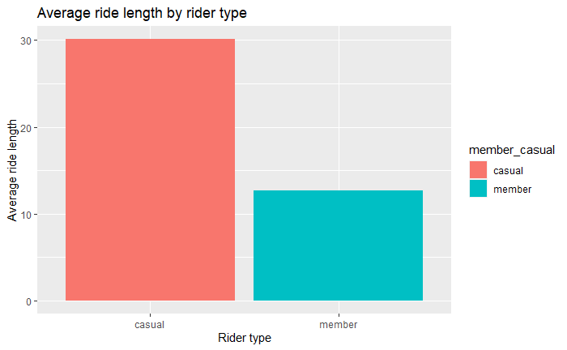

```r
combined_trips_v3 %>%
  group_by(member_casual) %>%
  summarise(Average_ride_length=mean(ride_length)) %>%
  ggplot(aes(x= member_casual, y=Average_ride_length, fill=member_casual)) + geom_col() + labs(title = "Average ride length by rider type", x="Rider type", y="Average ride length")
```

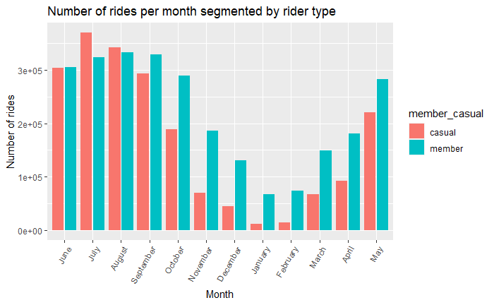

```r
combined_trips_v3 %>%
  group_by(member_casual, month) %>%
  summarise(number_of_rides=n(), average_ride_length=mean(ride_length))%>%
  ggplot (aes(x=month, y=number_of_rides, fill=member_casual)) + geom_col(position= "dodge2") + labs(title = "Number of rides per month segmented by rider type", x= "Month", y="Number of rides")+ theme(axis.text.x = element_text(angle = 60, hjust=1))
```

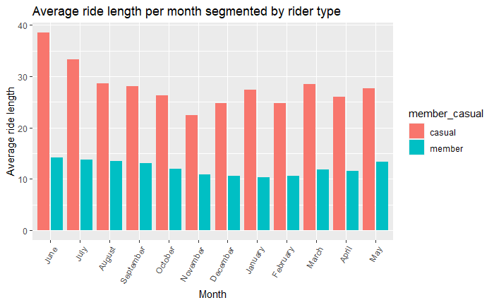

```r
combined_trips_v3 %>%
  group_by(member_casual, month) %>%
  summarise(number_of_rides=n(), average_ride_length=mean(ride_length))%>%
  ggplot (aes(x=month, y=average_ride_length, fill=member_casual)) + geom_col(position= "dodge2") + labs(title = "Average ride length per month segmented by rider type", x= "Month", y="Average ride length")+ theme(axis.text.x = element_text(angle = 60, hjust=1))
```

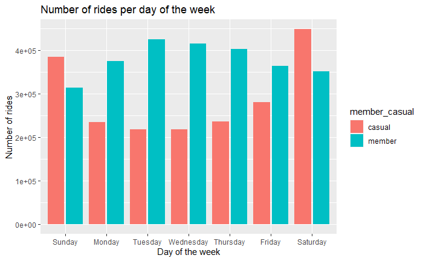

```r
combined_trips_v3 %>%
  group_by(member_casual, day_of_the_week) %>%
  summarise(number_of_rides=n(), average_ride_length=mean(ride_length))%>%
  ggplot (aes(x=day_of_the_week, y=number_of_rides, fill=member_casual)) + geom_col(position= "dodge2") + labs(title = "Number of rides per day of the week", x= "Day of the week", y="Number of rides")
```

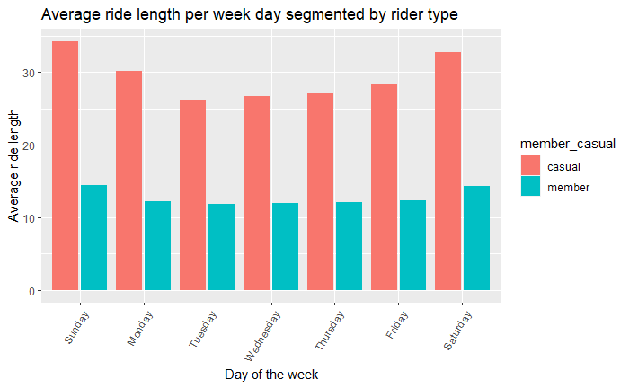

```r
combined_trips_v3 %>%
  group_by(member_casual, day_of_the_week) %>%
  summarise(number_of_rides=n(), average_ride_length=mean(ride_length))%>%
  ggplot (aes(x=day_of_the_week, y=average_ride_length, fill=member_casual)) + geom_col(position= "dodge2") + labs(title = "Average ride length per week day segmented by rider type", x= "Day of the week", y="Average ride length")+ theme(axis.text.x = element_text(angle = 60, hjust=1))
```

### Number of rides and Average ride length segmented by rideable type

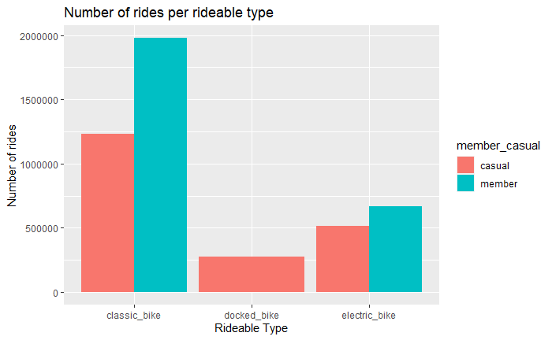

```r
combined_trips_v3 %>%
  group_by(rideable_type, member_casual) %>%
  summarise(number_of_rides=n()) %>%
  ggplot(aes(x=rideable_type, y=number_of_rides, fill=member_casual)) + geom_col(position = "dodge") + labs(title="Number of rides per rideable type" , x="Rideable Type", y="Number of rides")
```

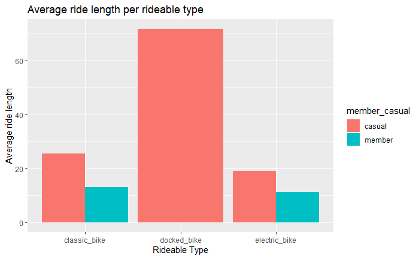

```r
combined_trips_v3 %>%
  group_by(rideable_type, member_casual) %>%
  summarise(Average_ride_length = mean(ride_length)) %>%
  ggplot(aes(x=rideable_type, y=Average_ride_length, fill=member_casual)) + geom_col(position = "dodge") + labs(title="Average ride length per rideable type" , x="Rideable Type", y="Average ride length")
```

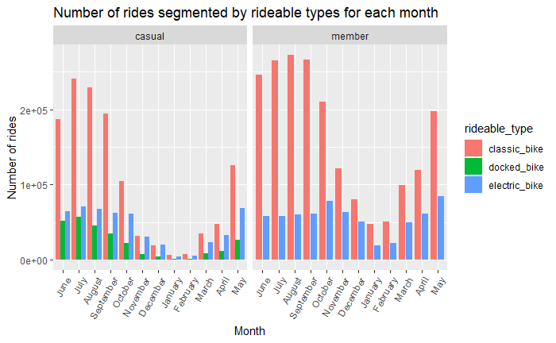

```r
combined_trips_v3 %>%
  group_by(member_casual, month, rideable_type) %>%
  summarise(number_of_rides=n(), average_ride_length=mean(ride_length))%>%
  ggplot (aes(x=month, y=number_of_rides, fill=rideable_type)) + geom_col(position="dodge2") + facet_wrap(~member_casual) + labs(title = "Number of rides segmented by rideable types for each month", x="Month", y="Number of rides") + theme(axis.text.x = element_text(angle = 60, hjust=1))
```

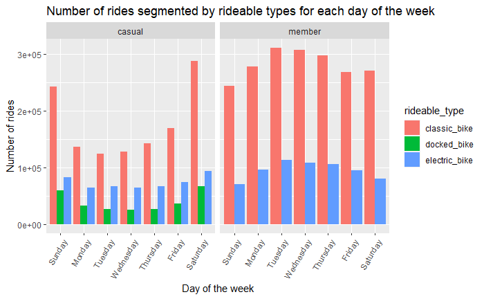

```r
combined_trips_v3 %>%
  group_by(member_casual, day_of_the_week, rideable_type) %>%
  summarise(number_of_rides=n(), average_ride_length=mean(ride_length))%>%
  ggplot (aes(x=day_of_the_week, y=number_of_rides, fill=rideable_type)) + geom_col(position = "dodge") + facet_wrap(~member_casual) + labs(title = "Number of rides segmented by rideable types for each day of the week", x="Day of the week", y="Number of rides") + theme(axis.text.x = element_text(angle = 60, hjust=1))
```

```r
head (combined_trips_v2)
```

| ride_id | rideable_type | started_at | ended_at | start_station_name | start_station_id | end_station_name | end_station_id | member_casual | date | month | day | year | day_of_the_week | ride_length |
| --- | --- | --- | --- | --- | --- | --- | --- | --- | --- | --- | --- | --- | --- | --- |
| 0D904FEC5F84A538 | classic_bike | 2021-06-04 07:29:18 | 2021-06-04 07:45:34 | Orleans St & Elm St | TA1306000006 | Orleans St & Elm St | TA1306000006 | member | 2021-06-04 | June | 04 | 2021 | Friday | 16.27 |
| C4185F300D6B552B | classic_bike | 2021-06-23 08:39:36 | 2021-06-23 08:41:37 | Desplaines St & Kinzie St | TA1306000003 | Kingsbury St & Kinzie St | KA1503000043 | member | 2021-06-23 | June | 23 | 2021 | Wednesday | 2.02 |
| 60F97090AC85F55E | classic_bike | 2021-06-27 12:26:58 | 2021-06-27 12:34:45 | Clark St & Grace St | TA1307000127 | Clark St & Leland Ave | TA1309000014 | member | 2021-06-27 | June | 27 | 2021 | Sunday | 7.78 |
| FBC7B1F0160AA304 | classic_bike | 2021-06-01 12:30:24 | 2021-06-01 12:33:02 | Kingsbury St & Kinzie St | KA1503000043 | Desplaines St & Kinzie St | TA1306000003 | member | 2021-06-01 | June | 01 | 2021 | Tuesday | 2.63 |
| 37A52001AEEFA4E5 | classic_bike | 2021-06-01 11:32:17 | 2021-06-01 11:34:43 | Desplaines St & Kinzie St | TA1306000003 | Kingsbury St & Kinzie St | KA1503000043 | member | 2021-06-01 | June | 01 | 2021 | Tuesday | 2.43 |
| E49E5426F0B74023 | classic_bike | 2021-06-17 17:55:12 | 2021-06-17 17:58:50 | Kingsbury St & Kinzie St | KA1503000043 | Desplaines St & Kinzie St | TA1306000003 | member | 2021-06-17 | June | 17 | 2021 | Thursday | 3.63 |

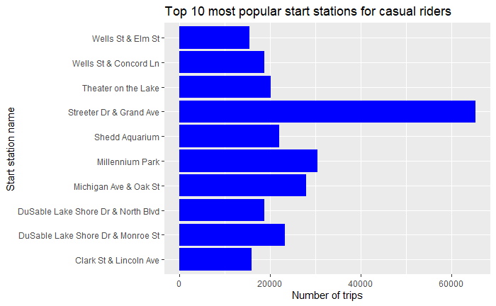

```r
combined_trips_v2 %>%
  group_by(start_station_name, member_casual) %>%
  summarise(number_of_trips=n()) %>%
  arrange(desc (number_of_trips)) %>%
  filter(member_casual== "casual", number_of_trips >= 15460) %>%
  select(start_station_name, number_of_trips) %>%
  ggplot(aes(x=start_station_name, y=number_of_trips)) + geom_col(fill="blue") + coord_flip() + labs(title="Top 10 most popular start stations for casual riders", x="Start station name", y="Number of trips")
```

```r
NA
```

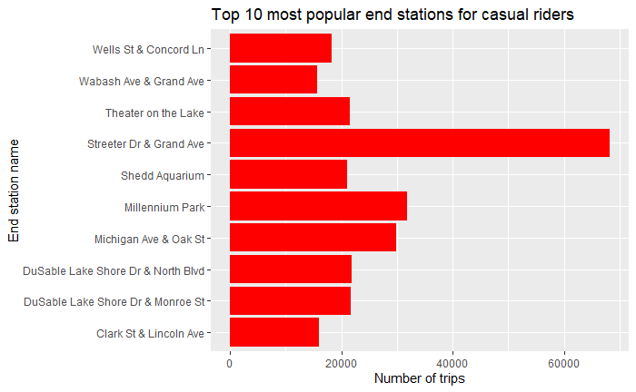

```r
combined_trips_v2 %>%
  group_by(end_station_name, member_casual) %>%
  summarise(number_of_trips=n()) %>%
  arrange(desc (number_of_trips)) %>%
  filter(member_casual== "casual", number_of_trips >= 15596) %>%
  select(end_station_name, number_of_trips) %>%
  ggplot(aes(x=end_station_name, y=number_of_trips)) + geom_col(fill="red") + coord_flip() + labs(title="Top 10 most popular end stations for casual riders", x="End station name", y="Number of trips")
```

```r
NA
```

The document, plots and tables are then exported for further analysis. Further visualisations also performed on Tableau. Saving the dataframes as CSV files on my local desktop.

```r
write.csv(top_routes,"C:\\Users\\Temi\\Desktop\\Cyclist project\\top_routes.csv", row.names=FALSE)
```

```r
write.csv(combined_trips_v3,"C:\\Users\\Temi\\Desktop\\Cyclist project\\combined_trips_v3.csv", row.names=FALSE)
```

```r
write.csv(top_routes_1,"C:\\Users\\Temi\\Desktop\\Cyclist project\\top_routes_1.csv", row.names=FALSE)
```

```r
write.csv(lat_lng1,"C:\\Users\\Temi\\Desktop\\Cyclist project\\lat_lng1.csv", row.names=FALSE)
```